# A Fine Wine…and What Makes It So

Brian

April 5, 2017

## Exploratory Data Analysis

This analysis will be structured as a stream of consciousness in that the majority of it will be graphical looks at the variables behind a red wine receiving a high quality rating. For a more complete and polished summary of the analysis, please see the bottom three graphs for substantial findings.

American wine making in the last 30 years has exploded and European wine making has existed for centuries at a very high level. Behind all the of subjective decisions a wine maker decides, this dataset shows that there is also reason to look at the chemical side of when to determine its quality. This dataset looks at nearly 1,600 wines and the 12 variables that accompany them.

```
## [1] 12
```

```
## [1] 1599
```

```
##  fixed.acidity   volatile.acidity  citric.acid    residual.sugar
##  Min.   : 4.60   Min.   :0.1200   Min.   :0.000   Min.   : 0.900
##  1st Qu.: 7.10   1st Qu.:0.3900   1st Qu.:0.090   1st Qu.: 1.900
##  Median : 7.90   Median :0.5200   Median :0.260   Median : 2.200
##  Mean   : 8.32   Mean   :0.5278   Mean   :0.271   Mean   : 2.539
##  3rd Qu.: 9.20   3rd Qu.:0.6400   3rd Qu.:0.420   3rd Qu.: 2.600
##  Max.   :15.90   Max.   :1.5800   Max.   :1.000   Max.   :15.500
##    chlorides       free.sulfur.dioxide total.sulfur.dioxide
##  Min.   :0.01200   Min.   : 1.00       Min.   :  6.00
##  1st Qu.:0.07000   1st Qu.: 7.00       1st Qu.: 22.00
##  Median :0.07900   Median :14.00       Median : 38.00
##  Mean   :0.08747   Mean   :15.87       Mean   : 46.47
##  3rd Qu.:0.09000   3rd Qu.:21.00       3rd Qu.: 62.00
##  Max.   :0.61100   Max.   :72.00       Max.   :289.00
##     density             pH          sulphates         alcohol
##  Min.   :0.9901   Min.   :2.740   Min.   :0.3300   Min.   : 8.40
##  1st Qu.:0.9956   1st Qu.:3.210   1st Qu.:0.5500   1st Qu.: 9.50
##  Median :0.9968   Median :3.310   Median :0.6200   Median :10.20
##  Mean   :0.9967   Mean   :3.311   Mean   :0.6581   Mean   :10.42
##  3rd Qu.:0.9978   3rd Qu.:3.400   3rd Qu.:0.7300   3rd Qu.:11.10
##  Max.   :1.0037   Max.   :4.010   Max.   :2.0000   Max.   :14.90
##     quality
##  Min.   :3.000
##  1st Qu.:5.000
##  Median :6.000
##  Mean   :5.636
##  3rd Qu.:6.000
##  Max.   :8.000
```

```
## 'data.frame':    1599 obs. of  12 variables:
##  $ fixed.acidity       : num  7.4 7.8 7.8 11.2 7.4 7.4 7.9 7.3 7.8 7.5 ...
##  $ volatile.acidity    : num  0.7 0.88 0.76 0.28 0.7 0.66 0.6 0.65 0.58 0.5 ...
##  $ citric.acid         : num  0 0 0.04 0.56 0 0 0.06 0 0.02 0.36 ...
##  $ residual.sugar      : num  1.9 2.6 2.3 1.9 1.9 1.8 1.6 1.2 2 6.1 ...
##  $ chlorides           : num  0.076 0.098 0.092 0.075 0.076 0.075 0.069 0.065 0.073 0.071 ...
##  $ free.sulfur.dioxide : num  11 25 15 17 11 13 15 15 9 17 ...
##  $ total.sulfur.dioxide: num  34 67 54 60 34 40 59 21 18 102 ...
##  $ density             : num  0.998 0.997 0.997 0.998 0.998 ...
##  $ pH                  : num  3.51 3.2 3.26 3.16 3.51 3.51 3.3 3.39 3.36 3.35 ...
##  $ sulphates           : num  0.56 0.68 0.65 0.58 0.56 0.56 0.46 0.47 0.57 0.8 ...
##  $ alcohol             : num  9.4 9.8 9.8 9.8 9.4 9.4 9.4 10 9.5 10.5 ...
##  $ quality             : int  5 5 5 6 5 5 5 7 7 5 ...
```

Looking at both the above summary and structure of the dataset allows us to have a general idea of the data before diving in and creating plots or subsets

## Univariate Plots

One of our most common y variables will be quality. Here is it’s distribution, looking fairly normal in nature:

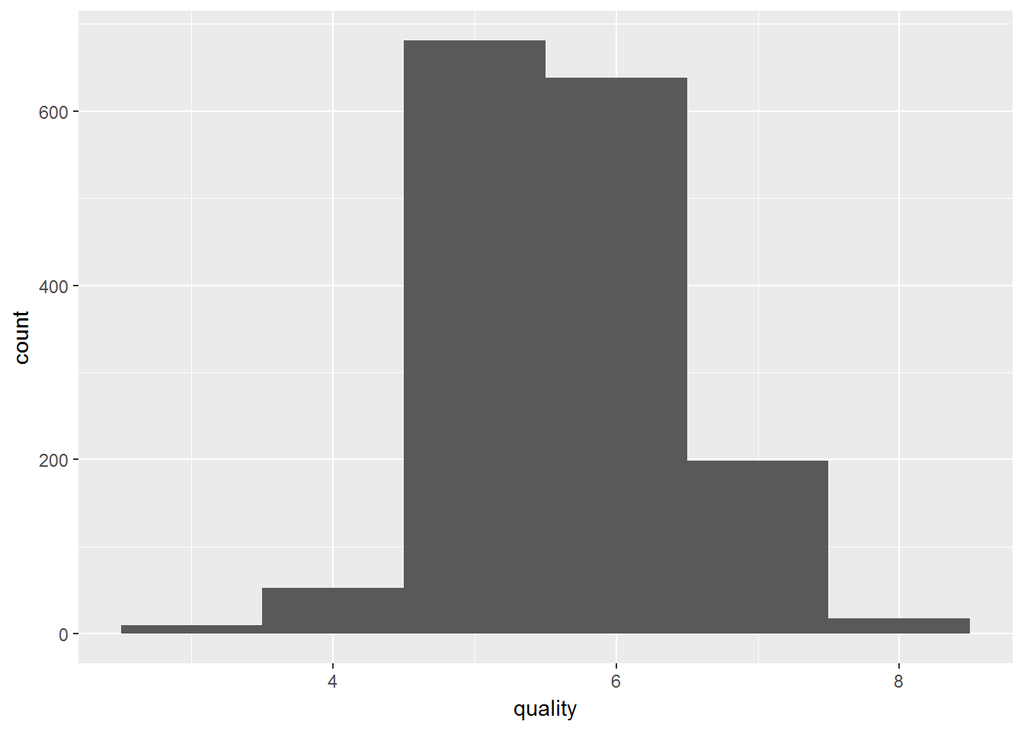

As we’ll be hoping to analyze many of the variables, it’ll be good to take a look at some additional distribtuions:

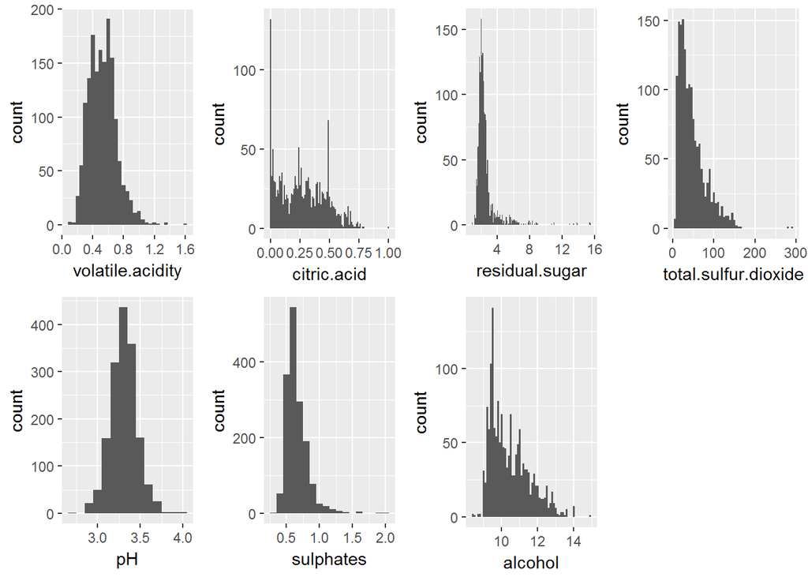

This approach gives a solid sense of which variables will need to be transformed once we start using them as well as a sense of where the majority of wines fall. Citric acid has a few outliers at 0 that might need to be cleaned up and pH levels are all very normally distributed.

I’d like to zoom in on the Citric acid outliers and see if we should remove them:

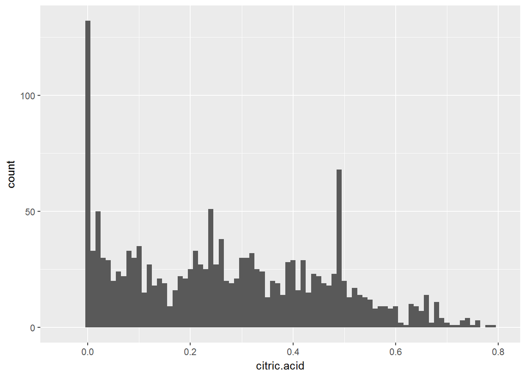

Zooming in you can see there are well over 100 wines with 0 citric acid so I think it’s safe to not consider them false data points. Further reseach has made it clear that wines often have no citric acid in them. These points will stay put for now.

I will now examine the residual sugars because of its long tail to the right. Perhaps it looks different without the outliers

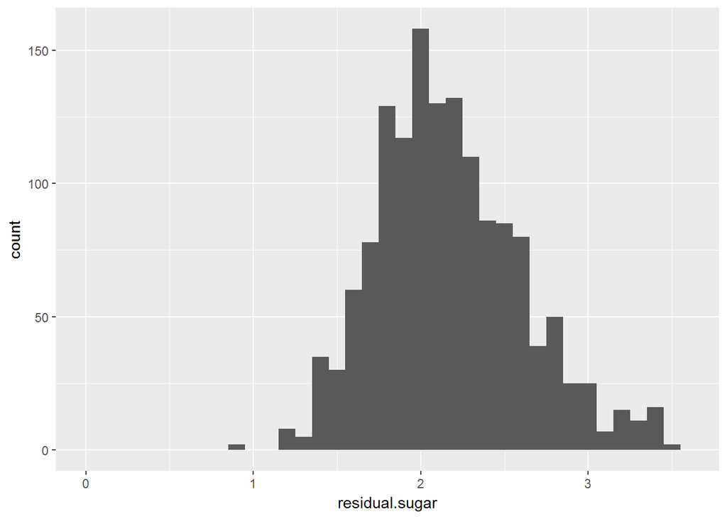

```
##    Min. 1st Qu.  Median    Mean 3rd Qu.    Max.
##   0.900   1.900   2.200   2.539   2.600  15.500
```

It is far more normal in distribution than it was before. Looking at its summary you can see the max of over 15. I wonder why some wines have such extremely high residual sugar levels when so many of them are clustered between 1.5 and 3.

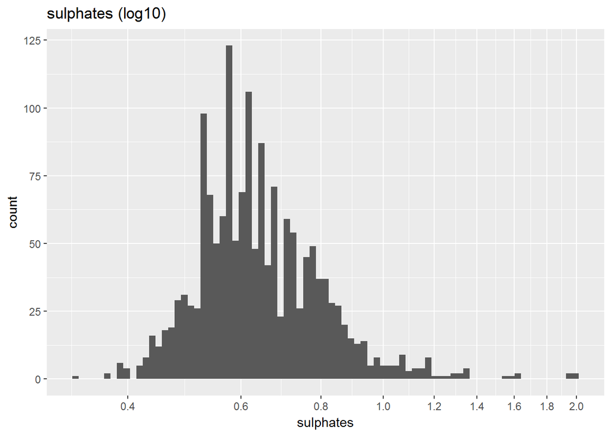

This was interesting to transform the sulphates and get a more normal distribution. My eye was first drawn to this variable as I’ve heard people say that sulphates are the reason people in America get headaches when drinking red wine but in Europe they don’t because they contain fewer sulphates. A quick Google search said that was an oversimplification but I’m still going to keep my eye on this variable.

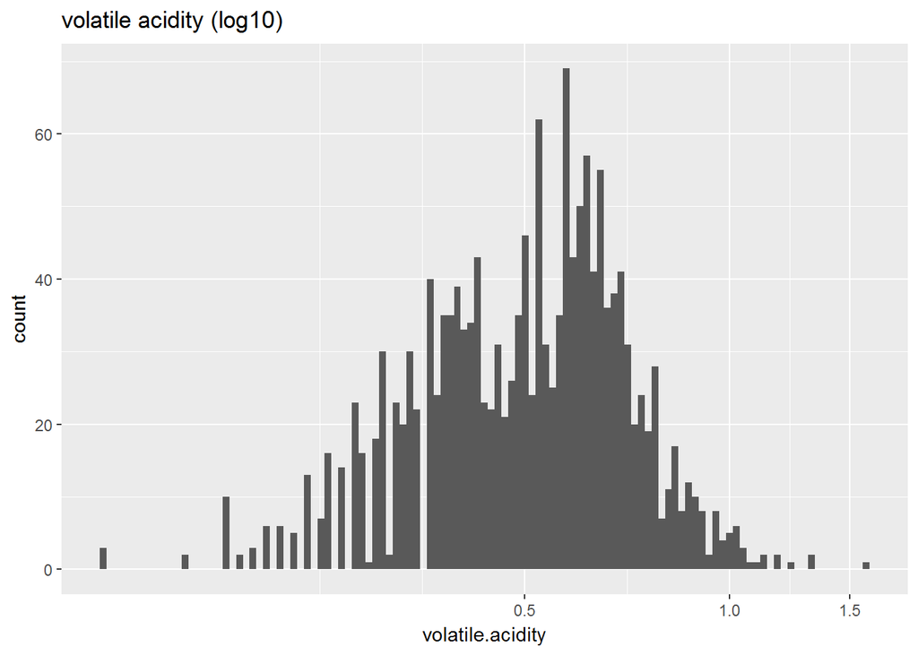

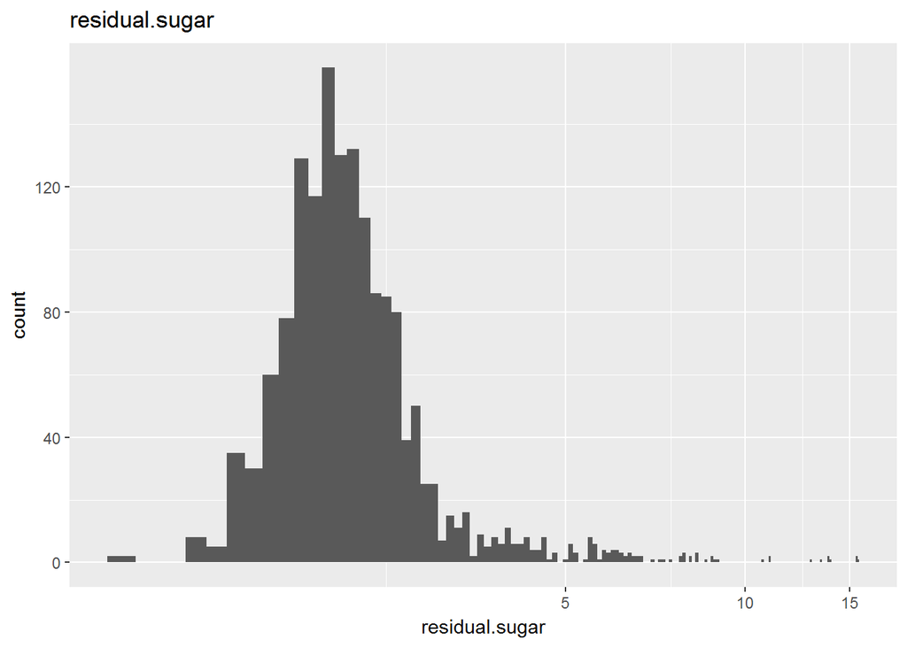

I went ahead and transformed 2 more variables in case it is needed when building a predictive model.

```
##    Min. 1st Qu.  Median    Mean 3rd Qu.    Max.
##    8.40    9.50   10.20   10.42   11.10   14.90
```

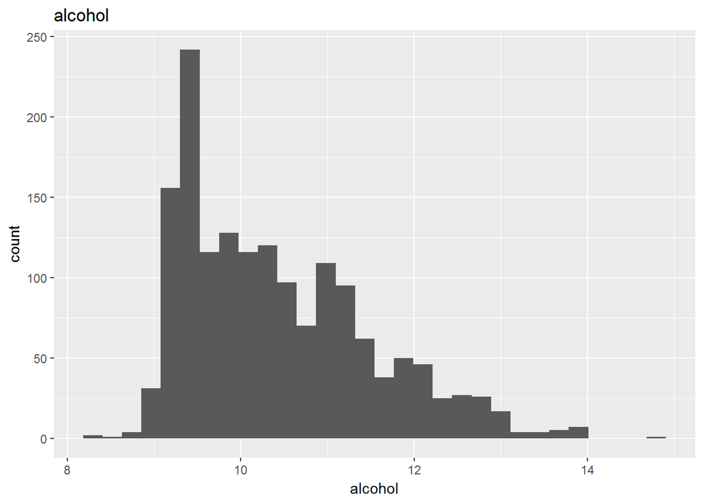

Taking a quick look at alcohol’s quantile stats you can see that the min amount of alcohol in a wine is 8.4 which means 8.4% of the wine’s volume. Alcohol % is often discussed when talking about beverages and can often add a bitterness to a drink it the % is high which is why I’m interested in this variable.  
The max of alcohol is 14.90 which leaves us with a great deal of variance with this variable and one that might prove to be powerful in prediction.

```
## [1] 0
```

Before moving on I did a quick check of missing values in this dataset and it’s abnormally complete. This will make trusting the data a bit easier moving forward.

### Univariate Summary:

What is the structure of your dataset?  
There are 1,599 wines in the dataset with 12 features (fixed acidity, volative acidity, citric acid, residual sugar, chlorides, free sulfur dioxide, total sulfur dioxide, density, pH, sulphates, alcohol, and quality). All variables are numeric variables.

Other observations:

The mean quality rating is 6 on a scale of 1-8 (with no wine receiving below a 3)  
Most wines have relatively low residual sugars with a few outliers much higher than the majority  
The median of pH falls at a 3.3 and it also the most common value  
Alcoholic content in wines is most commonly around 9 and 10, at the bottom of the spectrum

What is/are the main feature(s) of interest in your dataset?  
The main features in the data set are quality, sulphates, and alcohol.  
They are the most known variables and have great variability which I’m hoping will transfer into predictive power in a model.

What other features in the dataset do you think will help support your investigation into your feature(s) of interest?  
There is a chance that pH could also play into whether or not a high quality score was received seeing as acidity can easily be tasted in comparison to other variables such as density.

Did you create any new variables from existing variables in the dataset?  
I created two subsetted dataframes, one for dry wines and one for sweet wines. My hope was that they would lead to quantitatively different quality ratings but their means are very close to each other.

Of the features you investigated, were there any unusual distributions? Did you perform any operations on the data to tidy, adjust, or change the form of the data? If so, why did you do this? There were a few unusual distributions that I tried to normalize so that they could be more easily used in a regression model later on. I transformed sulphates with a log10 so that it went from being skewed to normal. I attempted to normalize alcohol but neither of the log10, sqrt, or reverse transformations truly made a difference.

## Bivariate Analysis

I wanted to take a look a the different on quality between’sweet’ and ‘dry’ wines. This seems to be determined by the amount of residual sugars left in the wine after the alcohol has fermented. To do so I created 2 new dataframes for each category of wine. The median amount was 2.2 and so I classified wines with more than 2.2 as sweet and those with less as dry. The  
mean difference between the two groups was only .07 and without a significance test, I’m not sure it really tells us anything. A dead end, but that’s not uncommon in EDA.

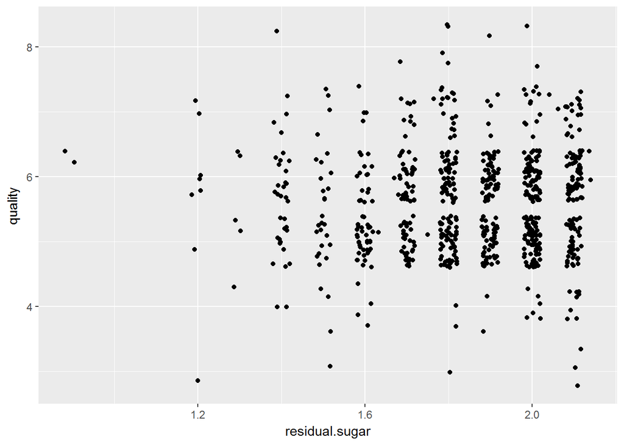

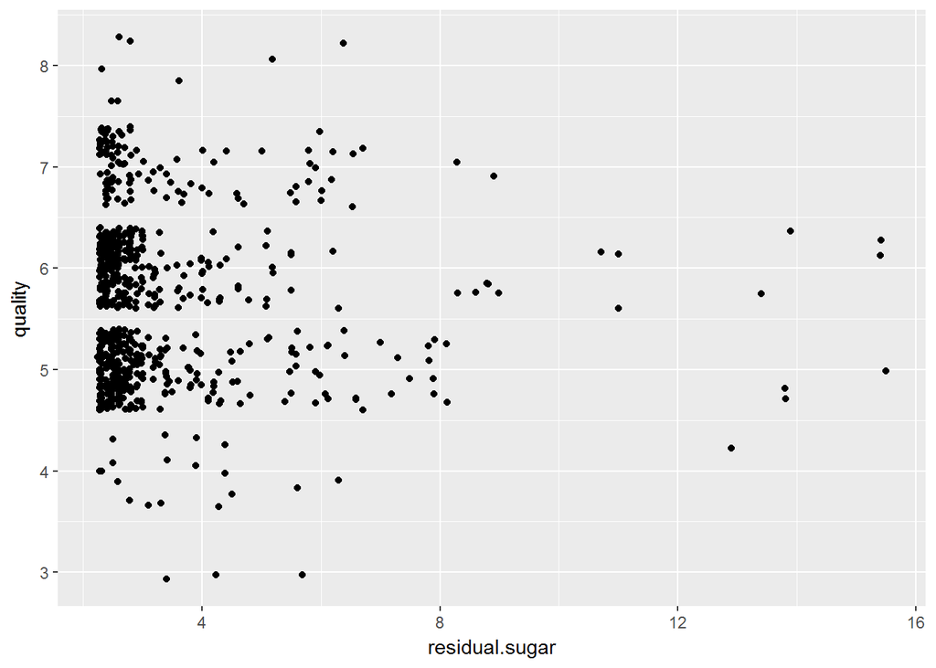

```
##    Min. 1st Qu.  Median    Mean 3rd Qu.    Max.
##   3.000   5.000   6.000   5.636   6.000   8.000
```

```
##    Min. 1st Qu.  Median    Mean 3rd Qu.    Max.
##   3.000   5.000   6.000   5.602   6.000   8.000
```

```
##    Min. 1st Qu.  Median    Mean 3rd Qu.    Max.
##   3.000   5.000   6.000   5.672   6.000   8.000
```

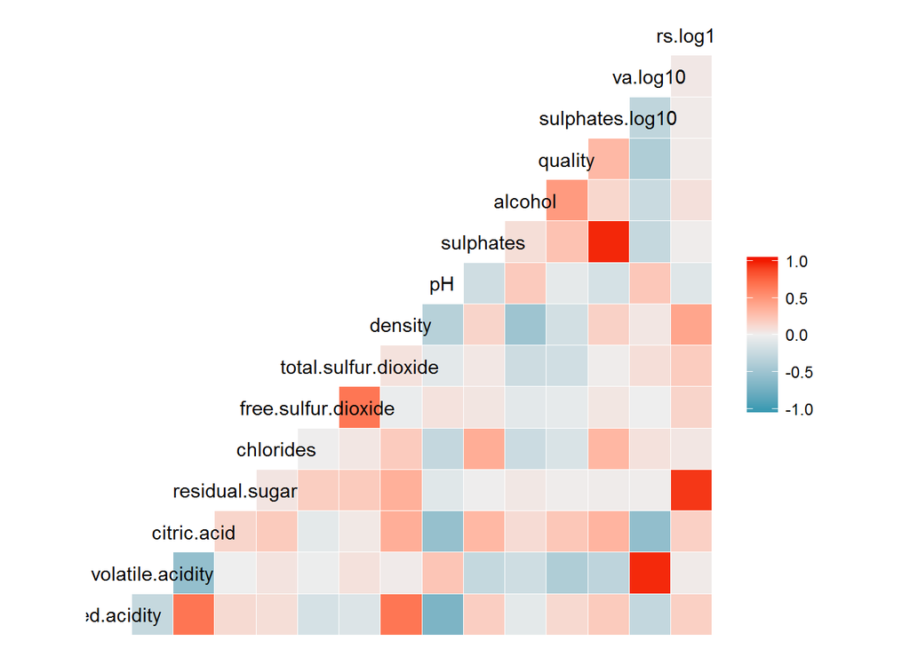

The above correlation plot allows us to very quickly spot variables that either have a positive or negative correation to each other. Several of these are only correlated because they are transformations of each other.  
Another type of visualization to see how variables interact is a mixed plot matrix. Let’s take a look at the inter-correlations below:

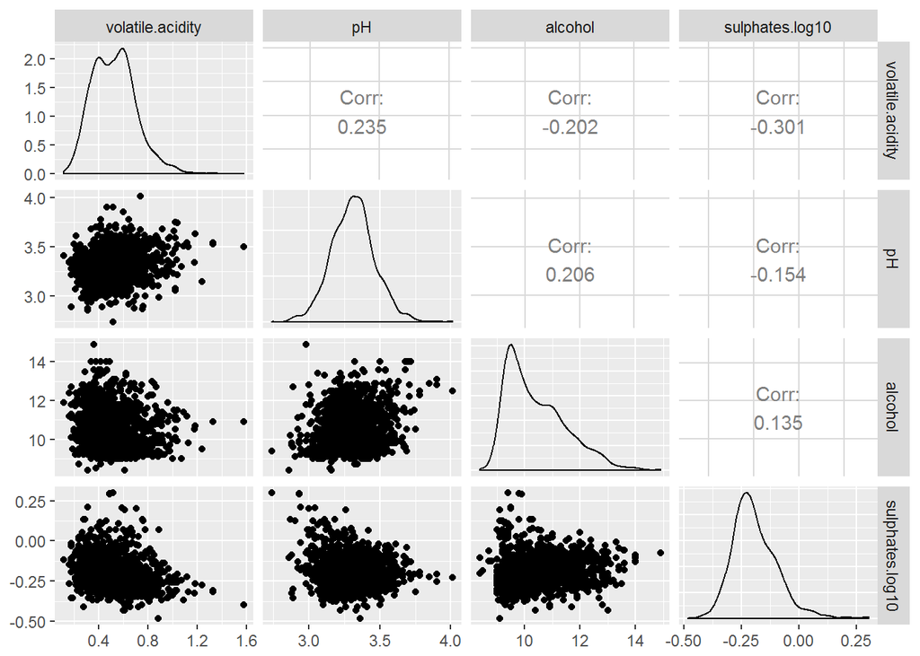

This plot shows that our inter-correlation of the independent variables is quite weak, which is a good thing for future modeling. It also highlights the fact that our distribution isn’t too skewed except for alcohol.

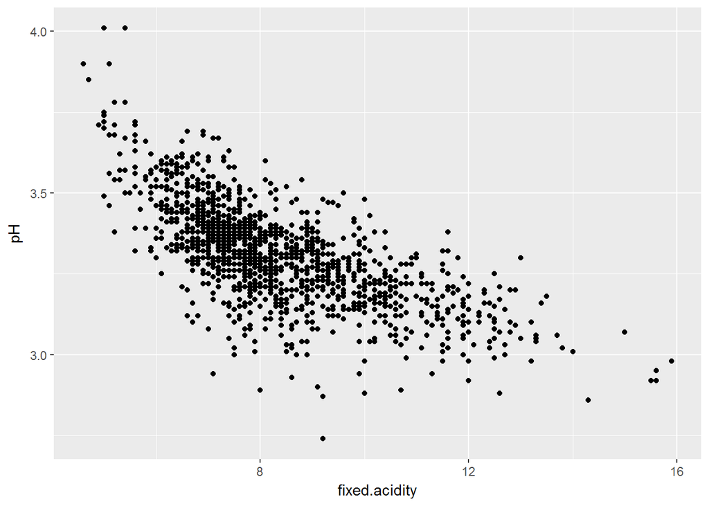

```
##
##  Pearson's product-moment correlation
##
## data:  wine$fixed.acidity and wine$pH
## t = -37.366, df = 1597, p-value < 2.2e-16
## alternative hypothesis: true correlation is not equal to 0
## 95 percent confidence interval:
##  -0.7082857 -0.6559174
## sample estimates:
##        cor
## -0.6829782
```

Here we see that two of our variables do have a strong interaction. Fixed acidity and pH which makes a lot of sense seeing as pH is our scale of how acid or base a substance is. It is always good to see assumptions about variable shown by statistical tests.

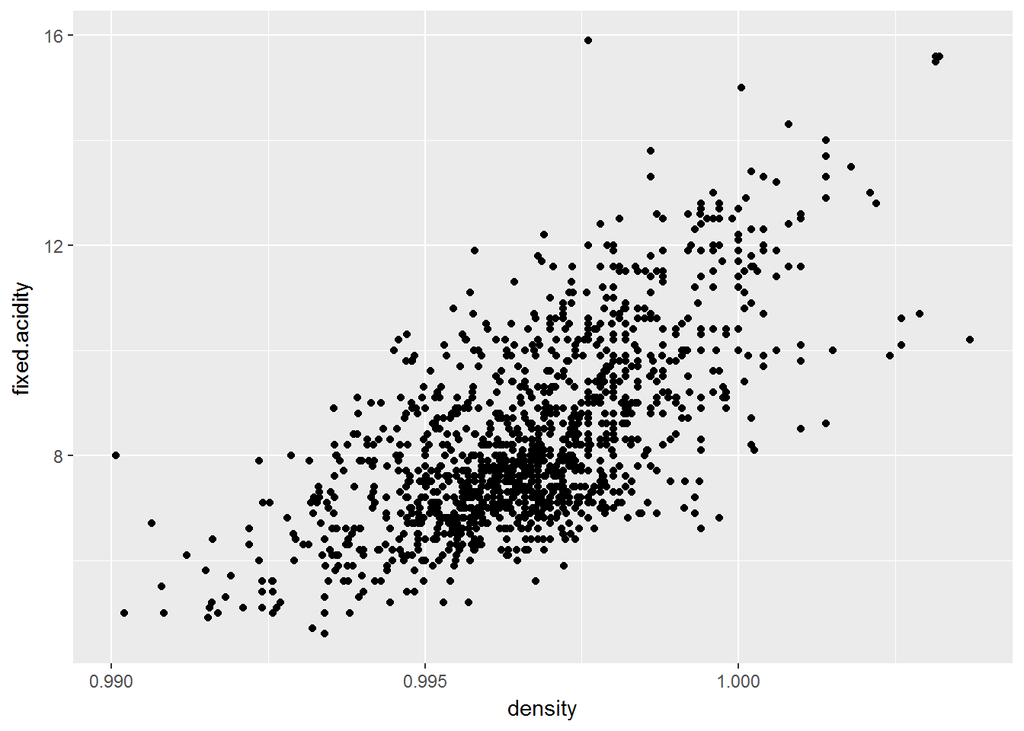

The density of wine seems fairly straightforward in reseach, the weight of the liquid by volume. It seems to be affected by a few ingredients such as alcohol, sugars, etc. Here we see that it’s either affecting the acidity or vice versa!

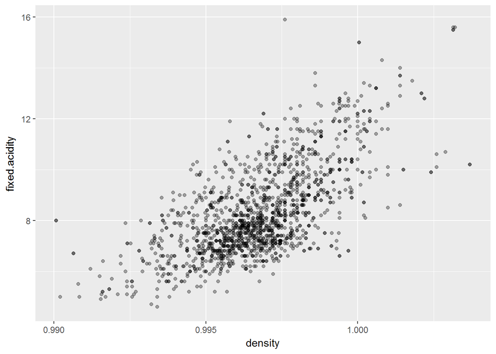

After adjusting the plot to take a closer look at concentrations of the data points, you can see that a majority of the density data is between 0.995 and 1.000. And yet even in that tightly clustered range you can see the positive correlation with fixed.acidity.

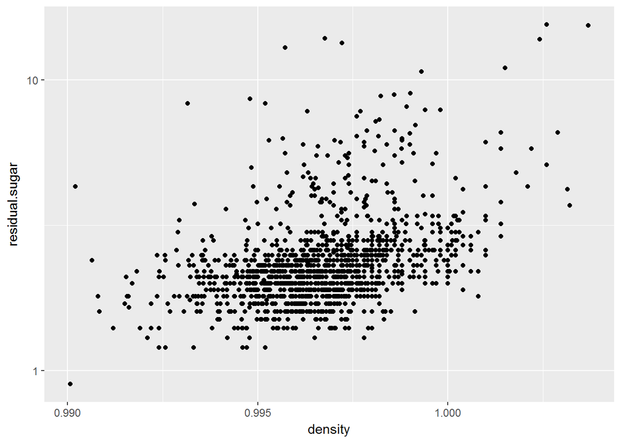

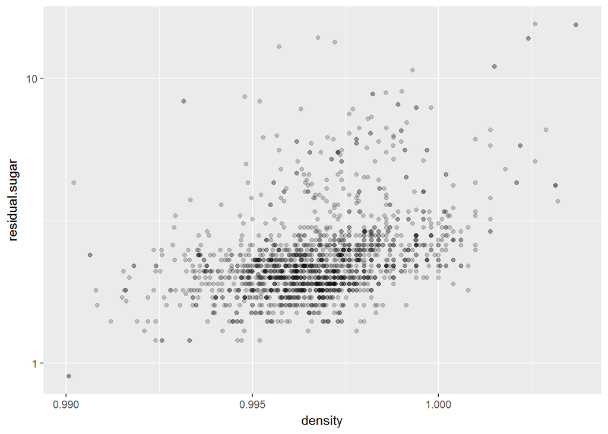

Here again you can see the clustering of the density data but this time with a much weaker correlation to residual.sugar. These variables with intercorrelation are helpful to view because they start to paint a picture of which variables might start to affect a regression model. I transformed the residual sugar variable on both above graphs because the data was skewed. It’s important to remember that highly correlated variables should not both be used in a linear regression model because that can cause undesired noise and interference.

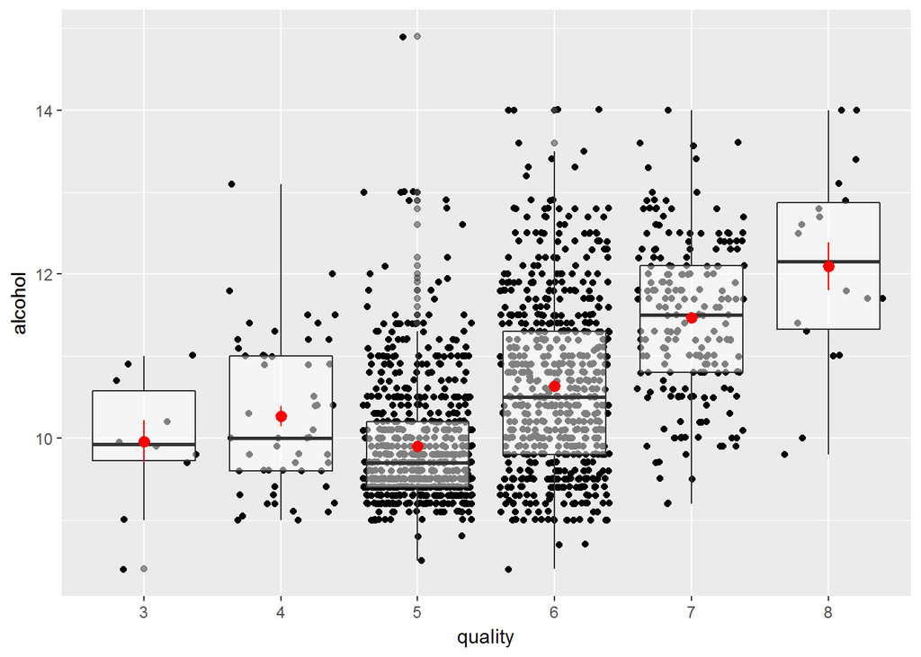

THe above graph is the first between an independent variable and the dependent variable of quality. The correlation between the two was .48 and so I expect to be using it to predict wine quality ratings. It is a little more difficult in the above graph to visualize relatedness because of the categorical nature of the dependent variable, but you are able to see that at max end of the quality spectrum there is a higher positive correlation. The boxplots are able to higlight this relationship along with the mean summary points.

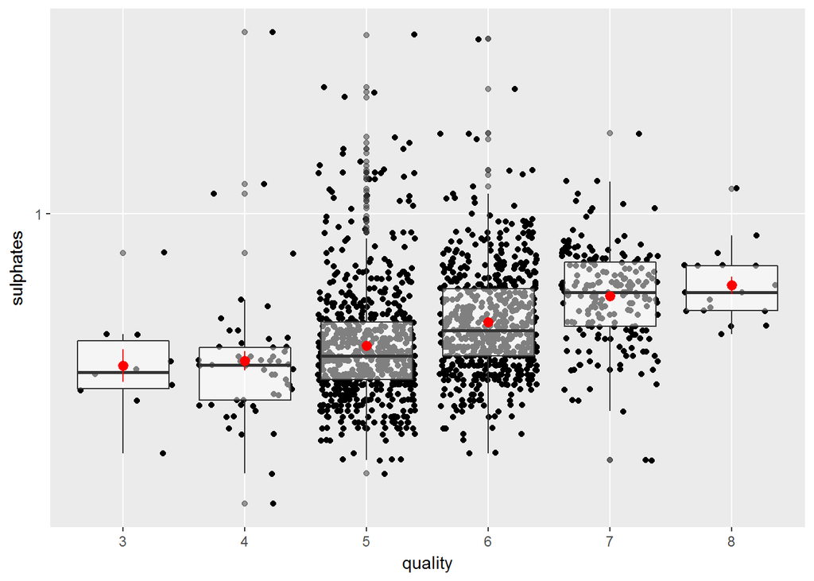

And here is a second graph between an independent variable and the quality metric. This graph demonstrates a slightly more consistent relationship as the boxplot illustrates that nearly every mean point of sulphates.log10 increases with the consequential quality rating

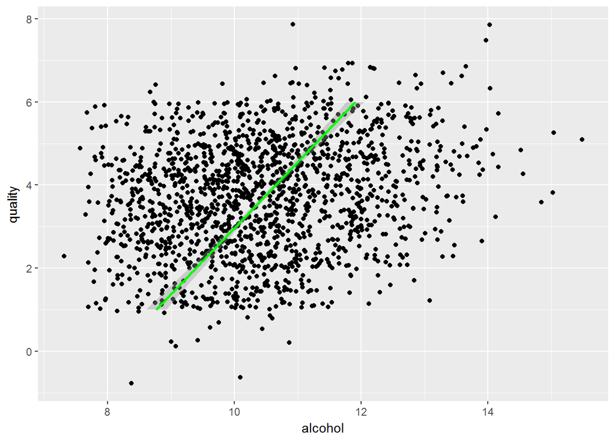

To help get a better picture of quality and alcohol’s relationship despite the difficulty with dealing with a categorical variable, I jittered the plot and added a linear best fit line. You can clearly see the positive relationship between the two.

```
## # A tibble: 6 × 5
##   quality alcohol_mean  pH_mean sulphates_mean     n
##     <dbl>        <dbl>    <dbl>          <dbl> <int>
## 1       1     9.955000 3.398000      0.5700000    10
## 2       2    10.265094 3.381509      0.5964151    53
## 3       3     9.899706 3.304949      0.6209692   681
## 4       4    10.629519 3.318072      0.6753292   638
## 5       5    11.465913 3.290754      0.7412563   199
## 6       6    12.094444 3.267222      0.7677778    18
```

Grouping by quality gave me a clear look at how a few different variables (at least their averages) interacted with the dependent variable. The graphs above also accomplished this, but sometimes it’s a bit clearer to see mean comparisons in numerical format side by side.

### Bivariate Summary

#### Talk about some of the relationships you observed in this part of the

#### investigation. How did the feature(s) of interest vary with other features in

#### the dataset?

An interestingly strong correlation was between quality and alcohol at 0.48

The second strongest correlatoin with quality was a negative correlation at -0.39

Density seemed to correlate strongly with a few different variables with one of them being acidity.

## Multivariate

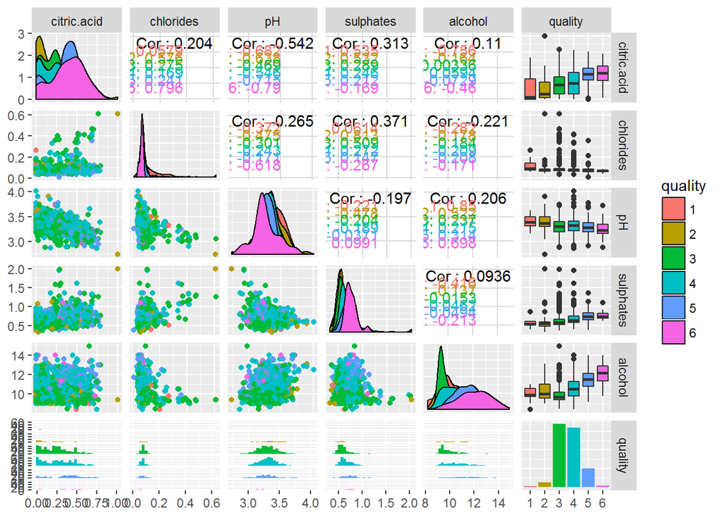

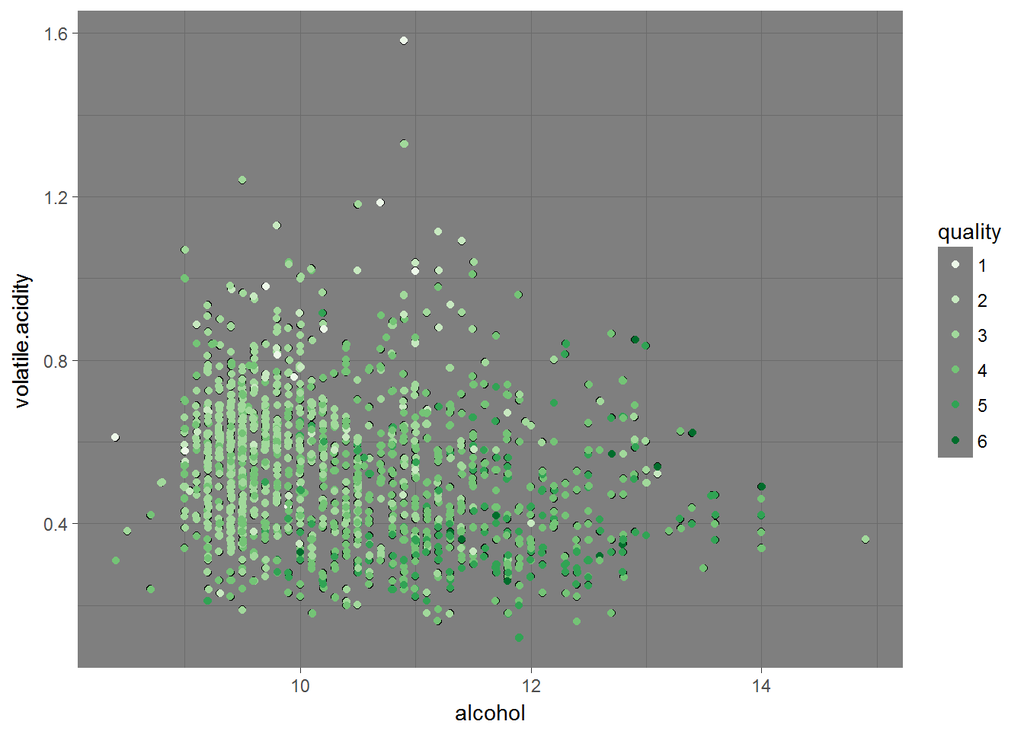

```
##
## Call:
## lm(formula = quality ~ alcohol + chlorides + citric.acid + density +
##     fixed.acidity + free.sulfur.dioxide + pH + rs.log10 + total.sulfur.dioxide +
##     sulphates.log10 + va.log10)
##
## Coefficients:
##          (Intercept)               alcohol             chlorides
##            30.303084              0.256644             -2.024078
##          citric.acid               density         fixed.acidity
##            -0.173001            -27.538980              0.018038
##  free.sulfur.dioxide                    pH              rs.log10
##             0.004237             -0.533833              0.207352
## total.sulfur.dioxide       sulphates.log10              va.log10
##            -0.003293              1.966877             -1.115228
```

```
##
## Call:
## lm(formula = quality ~ alcohol + chlorides + citric.acid + density +
##     fixed.acidity + free.sulfur.dioxide + pH + rs.log10 + total.sulfur.dioxide +
##     sulphates.log10 + va.log10)
##
## Residuals:
##      Min       1Q   Median       3Q      Max
## -2.65951 -0.36535 -0.03715  0.44524  1.91454
##
## Coefficients:
##                        Estimate Std. Error t value Pr(>|t|)
## (Intercept)           3.030e+01  2.301e+01   1.317  0.18807
## alcohol               2.566e-01  2.845e-02   9.020  < 2e-16 ***
## chlorides            -2.024e+00  4.113e-01  -4.921 9.48e-07 ***
## citric.acid          -1.730e-01  1.482e-01  -1.167  0.24340
## density              -2.754e+01  2.339e+01  -1.177  0.23931
## fixed.acidity         1.804e-02  2.605e-02   0.692  0.48875
## free.sulfur.dioxide   4.237e-03  2.150e-03   1.971  0.04894 *
## pH                   -5.338e-01  1.906e-01  -2.801  0.00516 **
## rs.log10              2.074e-01  1.480e-01   1.401  0.16133
## total.sulfur.dioxide -3.293e-03  7.269e-04  -4.531 6.32e-06 ***
## sulphates.log10       1.967e+00  2.004e-01   9.817  < 2e-16 ***
## va.log10             -1.115e+00  1.452e-01  -7.681 2.75e-14 ***
## ---
## Signif. codes:  0 '***' 0.001 '**' 0.01 '*' 0.05 '.' 0.1 ' ' 1
##
## Residual standard error: 0.6442 on 1587 degrees of freedom
## Multiple R-squared:  0.368,  Adjusted R-squared:  0.3636
## F-statistic: 83.99 on 11 and 1587 DF,  p-value: < 2.2e-16
```

Here we take a look at the model output. The R squared (strength) of the model is 0.368 which is not very powerful. That is to be considered give the fact that we simply through all of our variables (plus one transformation) into it. The power of a model comes when unecessary variables are taken out. By looking at the p values I narrowed down the model coefficients for round 2 below.

```
##
## Call:
## lm(formula = quality ~ alcohol + chlorides + volatile.acidity +
##     sulphates.log10 + pH + total.sulfur.dioxide + rs.log10 +
##     free.sulfur.dioxide + citric.acid)
##
## Residuals:
##      Min       1Q   Median       3Q      Max
## -2.68288 -0.36227 -0.03646  0.44381  1.97743
##
## Coefficients:
##                        Estimate Std. Error t value Pr(>|t|)
## (Intercept)           3.8543386  0.4614720   8.352  < 2e-16 ***
## alcohol               0.2870306  0.0171261  16.760  < 2e-16 ***
## chlorides            -1.9978973  0.3920916  -5.095 3.89e-07 ***
## volatile.acidity     -1.0360314  0.1164155  -8.899  < 2e-16 ***
## sulphates.log10       1.8494045  0.1897205   9.748  < 2e-16 ***
## pH                   -0.6094851  0.1320381  -4.616 4.23e-06 ***
## total.sulfur.dioxide -0.0032470  0.0006933  -4.683 3.06e-06 ***
## rs.log10              0.0734970  0.1091747   0.673   0.5009
## free.sulfur.dioxide   0.0042099  0.0021336   1.973   0.0486 *
## citric.acid          -0.2060523  0.1231380  -1.673   0.0945 .
## ---
## Signif. codes:  0 '***' 0.001 '**' 0.01 '*' 0.05 '.' 0.1 ' ' 1
##
## Residual standard error: 0.6422 on 1589 degrees of freedom
## Multiple R-squared:  0.3712, Adjusted R-squared:  0.3677
## F-statistic: 104.2 on 9 and 1589 DF,  p-value: < 2.2e-16
```

This time the model is able to predict over 37% of red wine qualities. This is not a considerably powerful model nor a marked improvement over the first model with its predictive power of 36%. Further, more specific transformations of variables along with a great knowledge of wine industry could considerably improve this attempt.

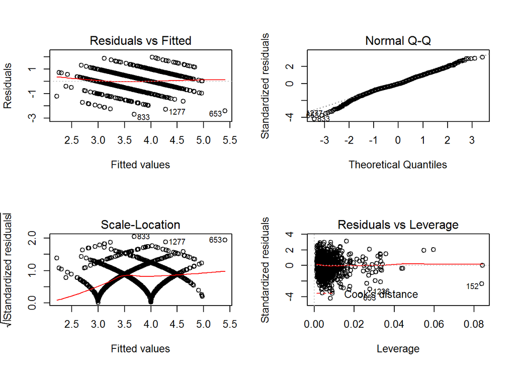

This plot of our residuals from the linear regression model allows us to do a quick spot check. Although the residuals graph in the upper left looks different than most because of the categorical nature of the dependent variables, one still can see that it is roughly a normal distribution.

### Multivariate Summary

#### Talk about some of the relationships you observed in this part of the

#### investigation. Were there features that strengthened each other in terms of

#### looking at your feature(s) of interest?

The relationship between alcohol content and quality continued to be strengthened by additional plots. Even when weaving in volatile acidity, the correlation seemed to point more towards alcohol doing the work in adjusting quality.

## Final Plots and Summary

### Plot 1

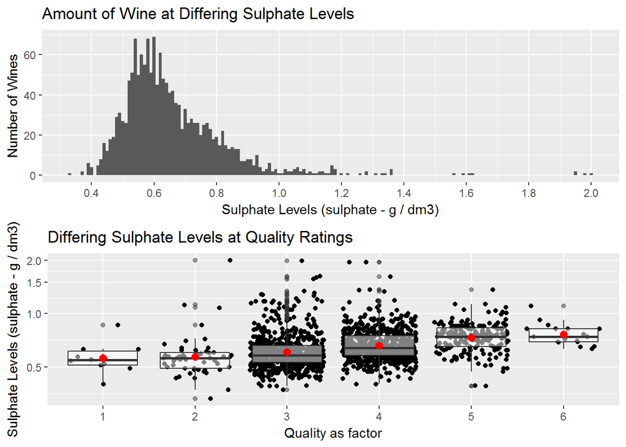

### Description 1

The distribution of the sulphate variable is very skewed before transformation. This graph is a log10 transformation of it because of its significance in regards to determing the quality of a red wine. This significance is shown in the boxplot portion where you can see the positive correlation between sulphate levels and wine quality ratings.

## Plot 2

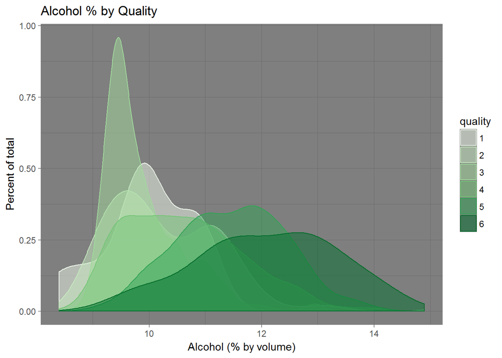

### Description Plot 2

The second plot is an extension of the plot matrix in the Multivariate Analysis section. It is an easy way to identify the relationship between alcohol and quality as you can see that the majority of wines with a quality of 3 are below 10% alcohol while many of the 5s and 6s are above 11.

## Plot 3

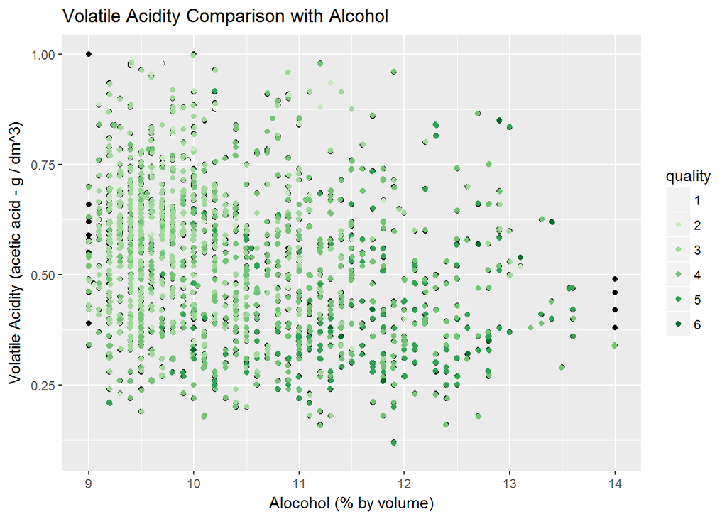

### Description Plot 3

This plot shows that both volatile acidity and alcohol play a part in the quality of a wine, but that alcohol is a stronger relationship. In addition, wines that have more alcohol tend to have a lower volatile acidity. The correlation between volatile acidity and alcohol is -0.2 but there obviously are still findings within the graph that are worthwhile. The fact that alcohol is positively correlated with quality and volatile acidity is negatively correlated to quality is concisely shown in one graph.

## Reflection

The red wine quality dataset that I explored has nearly 1,600 datapoints to examine spread out across 12 different variables. The majority of the variables were numeric with one being factorl, the variable of quality. I first made several histograms to get a feel for the distribution of the data and then performed a few transformations on it to aide in eventually fitting it to a linear regression model. The data was very complete and did not take additional cleaning.

I placed wines into 2 groups, one for sweet wines and one for dry wines. This grouping did not seem to show any strong differences between the two. I also group the wines based on their quality datapoint and looked at the differences in means of variables between them. This was helpful confirmation when deciding on most powerful explanatory variables.

I was unable to do as much intervariable analysis because so many of the variables were numeric instead of factoral. The fact that quality was factoral did help in the end as I examined a few plots with the extra layer of quality on top.

Several variables stood out very quickly in terms of being highly correlated with quality. A correlation matrix was very helpful in determining those datapoints. Alcohol, volatile acidity, and sulphates were all correlated with quality and ended up being variables in the regression model. Suprisingly so, there were a few variables that also contributed to the model that I did not expect such as chlorides. All told, though, the model was not very powerful and was able to only explain about 37% of the datapoints.

The dataset does have its downsides with one of them being only one quality rating. If the point of collecting so many different wines and their properties is to see which elements affect the rating they receive, it would be very helpful to have 5 or more ratings and then to take an average of the spread. Without this, one has to assume that the only quality rating a wine received is the absolute truth for that wine. Lastly, the region breakdown of the wines would be helpful to examine. One place I read online said that this dataset all came from Portugal. If that is the case, one could examine which wines have properties that are consistent with others in their area and if certain areas receive higher quality rankings than others.